# Full_Code_AIML_USL_Project_CreditCardCustomerSegmentation

## Problem Statement

### Context

AllLife Bank wants to focus on its credit card customer base in the next financial year. They have been advised by their marketing research team, that the penetration in the market can be improved. Based on this input, the Marketing team proposes to run personalized campaigns to target new customers as well as upsell to existing customers. Another insight from the market research was that the customers perceive the support services of the back poorly. Based on this, the Operations team wants to upgrade the service delivery model, to ensure that customer queries are resolved faster. Head of Marketing and Head of Delivery both decide to reach out to the Data Science team for help

### Objective

To identify different segments in the existing customer, based on their spending patterns as well as past interaction with the bank, using clustering algorithms, and provide recommendations to the bank on how to better market to and service these customers.

### Data Description

The data provided is of various customers of a bank and their financial attributes like credit limit, the total number of credit cards the customer has, and different channels through which customers have contacted the bank for any queries (including visiting the bank, online and through a call center).

**Data Dictionary**

- Sl_No: Primary key of the records
- Customer Key: Customer identification number
- Average Credit Limit: Average credit limit of each customer for all credit cards
- Total credit cards: Total number of credit cards possessed by the customer
- Total visits bank: Total number of Visits that customer made (yearly) personally to the bank
- Total visits online: Total number of visits or online logins made by the customer (yearly)
- Total calls made: Total number of calls made by the customer to the bank or its customer service department (yearly)

## Importing necessary libraries and data

```python
import numpy as np
import pandas as pd
import matplotlib.pyplot as plt
import seaborn as sns
from sklearn.model_selection import train_test_split
from sklearn.cluster import KMeans
from sklearn.cluster import AgglomerativeClustering
from scipy.stats import zscore
from sklearn.decomposition import PCA
from scipy.cluster.hierarchy import dendrogram, linkage, cophenet
from scipy.spatial.distance import pdist

from google.colab import drive
drive.mount('/content/drive')

df = pd.read_excel('/content/drive/MyDrive/Credit+Card+Customer+Data.xlsx')
```

## Data Overview

- Observations
- Sanity checks

```python
df.info()
```

```
<class 'pandas.core.frame.DataFrame'>
RangeIndex: 660 entries, 0 to 659
Data columns (total 7 columns):
 #   Column               Non-Null Count  Dtype
---  ------               --------------  -----
 0   Sl_No                660 non-null    int64
 1   Customer Key         660 non-null    int64
 2   Avg_Credit_Limit     660 non-null    int64
 3   Total_Credit_Cards   660 non-null    int64
 4   Total_visits_bank    660 non-null    int64
 5   Total_visits_online  660 non-null    int64
 6   Total_calls_made     660 non-null    int64
dtypes: int64(7)
memory usage: 36.2 KB
```

There are 660 rows and 7 columns. All integers. No missing values.

```python
df.head()
```

|  | Sl_No | Customer Key | Avg_Credit_Limit | Total_Credit_Cards | Total_visits_bank | Total_visits_online | Total_calls_made |
| --- | --- | --- | --- | --- | --- | --- | --- |
| 0 | 1 | 87073 | 100000 | 2 | 1 | 1 | 0 |
| 1 | 2 | 38414 | 50000 | 3 | 0 | 10 | 9 |
| 2 | 3 | 17341 | 50000 | 7 | 1 | 3 | 4 |
| 3 | 4 | 40496 | 30000 | 5 | 1 | 1 | 4 |
| 4 | 5 | 47437 | 100000 | 6 | 0 | 12 | 3 |

```python
# drop duplicates

df_no_duplicates = df.drop_duplicates('Sl_No', keep='first', inplace=True)
df_no_duplicates = df.drop_duplicates('Customer Key', keep='first', inplace=True)
df.reset_index(drop=True, inplace=True)
```

```python
# drop unnecessary columns

df.drop(['Sl_No', 'Customer Key'], axis=1, inplace=True)
```

```python
df.info()
```

```
<class 'pandas.core.frame.DataFrame'>
RangeIndex: 655 entries, 0 to 654
Data columns (total 5 columns):
 #   Column               Non-Null Count  Dtype
---  ------               --------------  -----
 0   Avg_Credit_Limit     655 non-null    int64
 1   Total_Credit_Cards   655 non-null    int64
 2   Total_visits_bank    655 non-null    int64
 3   Total_visits_online  655 non-null    int64
 4   Total_calls_made     655 non-null    int64
dtypes: int64(5)
memory usage: 25.7 KB
```

This is our new dataframe after deleting duplicates. There are now 655 rows and 5 columns.

## Exploratory Data Analysis (EDA)

- EDA is an important part of any project involving data.
- It is important to investigate and understand the data better before building a model with it.
- A few questions have been mentioned below which will help you approach the analysis in the right manner and generate insights from the data.
- A thorough analysis of the data, in addition to the questions mentioned below, should be done.

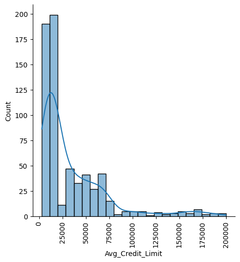

```python
sns.displot(df['Avg_Credit_Limit'], kde=True);
plt.xticks(rotation=90);
```

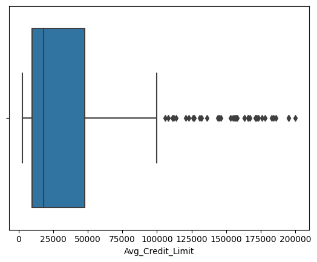

```python
sns.boxplot(x='Avg_Credit_Limit', data=df);
```

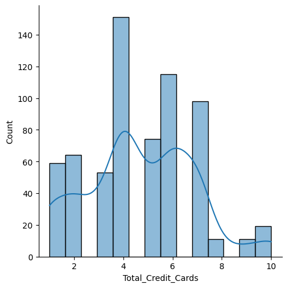

```python
sns.displot(df['Total_Credit_Cards'], kde=True);
```

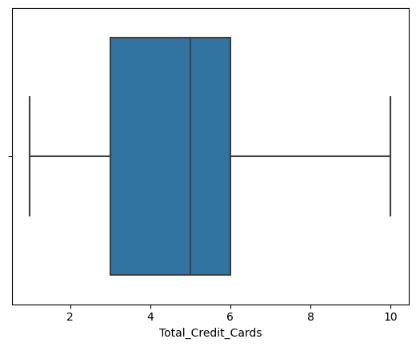

```python
sns.boxplot(x='Total_Credit_Cards', data=df);
```

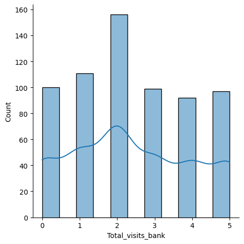

```python
sns.displot(df['Total_visits_bank'], kde=True);
```

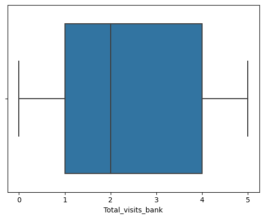

```python
sns.boxplot(x='Total_visits_bank', data=df);
```

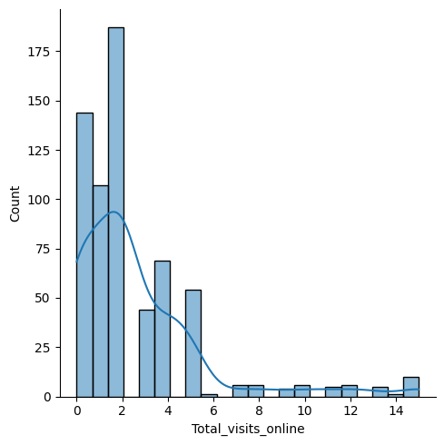

```python
sns.displot(df['Total_visits_online'], kde=True);
```

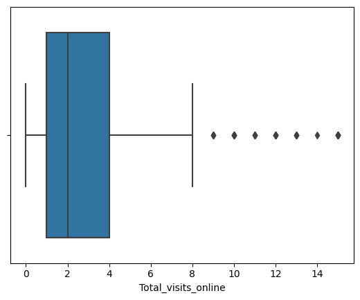

```python
sns.boxplot(x='Total_visits_online', data=df);
```

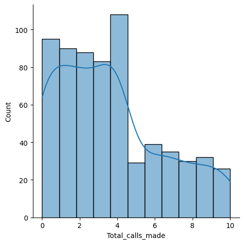

```python
sns.displot(df['Total_calls_made'], kde=True);
```

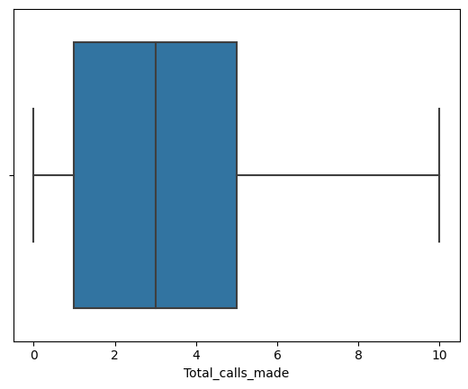

```python
sns.boxplot(x='Total_calls_made', data=df);
```

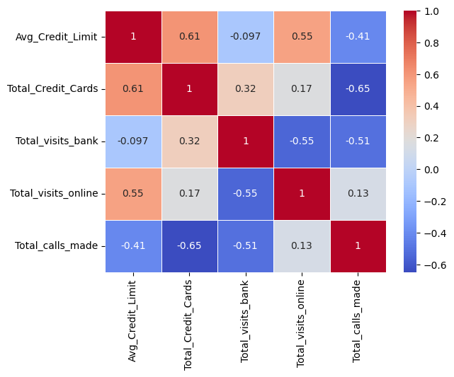

```python
sns.heatmap(df.corr(), annot=True, cmap='coolwarm', linewidths=0.5);
```

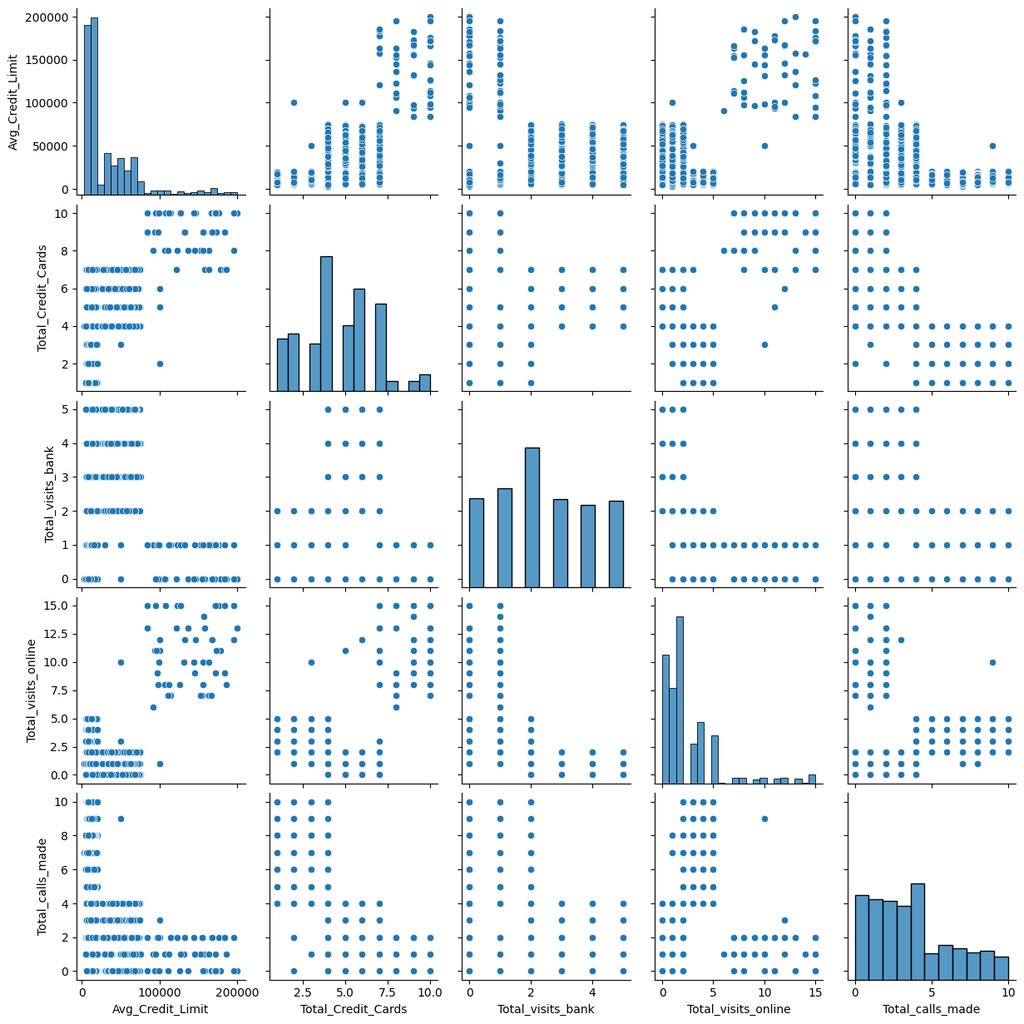

```python
sns.pairplot(df);
```

## Data Preprocessing

- Duplicate value check
- Missing value treatment
- Outlier check
- Feature engineering (if needed)
- Any other preprocessing steps (if needed)

```python
# perform zscore normalization

df_zscore = df.apply(zscore)
df_zscore.head()
```

|  | Avg_Credit_Limit | Total_Credit_Cards | Total_visits_bank | Total_visits_online | Total_calls_made |
| --- | --- | --- | --- | --- | --- |
| 0 | 1.767076 | -1.241704 | -0.858568 | -0.546642 | -1.257006 |
| 1 | 0.423440 | -0.780379 | -1.471163 | 2.516526 | 1.884177 |
| 2 | 0.423440 | 1.064922 | -0.858568 | 0.134062 | 0.139075 |
| 3 | -0.114014 | 0.142271 | -0.858568 | -0.546642 | 0.139075 |
| 4 | 1.767076 | 0.603597 | -1.471163 | 3.197230 | -0.209945 |

```python
# calculate covariance matrix

df_zscore_cov = np.cov(df_zscore, rowvar=False)
print(df_zscore_cov)
```

```
[[ 1.00152905  0.61194937 -0.0976107   0.5525838  -0.41332174]
 [ 0.61194937  1.00152905  0.31678969  0.16840089 -0.65032346]
 [-0.0976107   0.31678969  1.00152905 -0.55293582 -0.50973981]
 [ 0.5525838   0.16840089 -0.55293582  1.00152905  0.12917822]
 [-0.41332174 -0.65032346 -0.50973981  0.12917822  1.00152905]]
```

```python
# perform PCA

pca = PCA(n_components=5)
df_pca = pca.fit_transform(df_zscore)

print(pca.explained_variance_)
```

```
[2.29114803 1.87485865 0.31971496 0.27835535 0.24356827]
```

```python
print(pca.components_)
```

```
[[ 0.48804703  0.59743217  0.28378954  0.1094746  -0.55889507]
 [ 0.40475615  0.03378783 -0.58474844  0.66583768  0.22307013]
 [-0.00569294 -0.2908224  -0.6077434  -0.28744673 -0.6807439 ]
 [ 0.29342893 -0.73563525  0.45312634  0.3354097  -0.23434396]
 [-0.71543665  0.12726465  0.05345314  0.59122771 -0.3457552 ]]
```

```python
print(pca.explained_variance_ratio_)
```

```
[0.45753002 0.37439925 0.06384537 0.05558608 0.04863928]
```

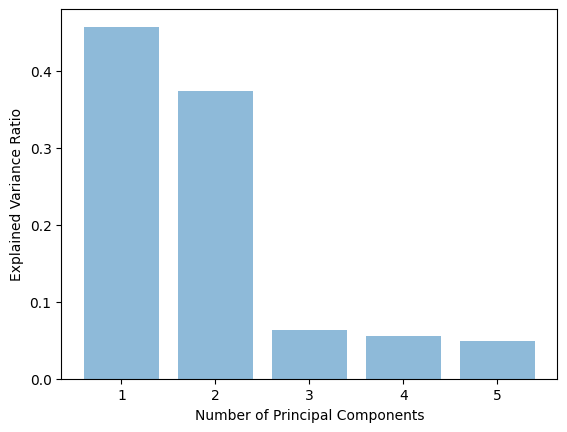

```python
plt.bar(list(range(1, 6)), pca.explained_variance_ratio_, alpha=0.5, align='center')
plt.xlabel('Number of Principal Components')
plt.ylabel('Explained Variance Ratio');
```

```python
#reduce to 2 principal component

pca2 = PCA(n_components=2)
pca2.fit(df_zscore)
print(pca2.components_)
```

```
[[ 0.48804703  0.59743217  0.28378954  0.1094746  -0.55889507]
 [ 0.40475615  0.03378783 -0.58474844  0.66583768  0.22307013]]
```

```python
print(pca2.explained_variance_ratio_)
```

```
[0.45753002 0.37439925]
```

```python
df_pca2 = pca2.transform(df_zscore)
print(df_pca2)
```

```
[[ 0.51962054  0.53095172]
 [-1.45462698  3.10118462]
 [ 0.53617261  0.82970507]
 ...
 [ 2.86647915  3.00474483]
 [ 4.19043448  4.61145463]
 [ 3.173489    4.37555127]]
```

## EDA

- It is a good idea to explore the data once again after manipulating it.

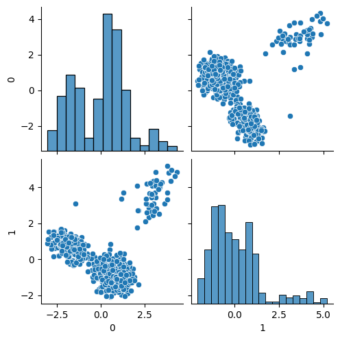

```python
sns.pairplot(pd.DataFrame(df_pca2));
```

You can see clusters already.

## K-means Clustering

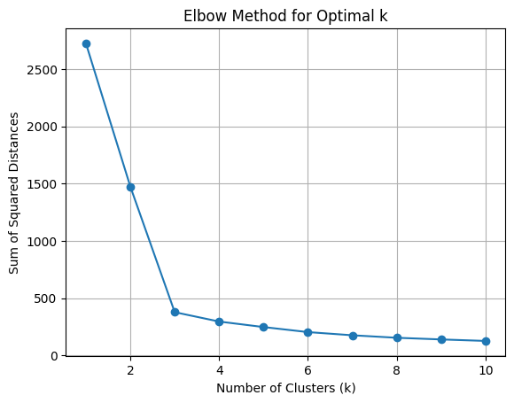

```python
# find optimal k with elbow method

sum_of_squared = []
k_range = range(1, 11)

for k in k_range:
    kmeans = KMeans(n_clusters=k, n_init=10, random_state=42)
    kmeans.fit(df_pca2)
    sum_of_squared.append(kmeans.inertia_)

plt.plot(k_range, sum_of_squared, marker='o')
plt.xlabel('Number of Clusters (k)')
plt.ylabel('Sum of Squared Distances')
plt.title('Elbow Method for Optimal k')
plt.grid(True)
plt.show()
```

The optimal k is 3.

```python
# execute K-means cluster on the reduced data

num_clusters = 3
kmeans = KMeans(n_clusters=num_clusters, n_init=10, random_state=2)
kmeans_predict = kmeans.fit_predict(df_pca2)

# append the prediction to data frame

df['GROUP'] = kmeans_predict
df_zscore['GROUP'] = kmeans_predict
df.head()
```

|  | Avg_Credit_Limit | Total_Credit_Cards | Total_visits_bank | Total_visits_online | Total_calls_made | GROUP |
| --- | --- | --- | --- | --- | --- | --- |
| 0 | 100000 | 2 | 1 | 1 | 0 | 1 |
| 1 | 50000 | 3 | 0 | 10 | 9 | 0 |
| 2 | 50000 | 7 | 1 | 3 | 4 | 1 |
| 3 | 30000 | 5 | 1 | 1 | 4 | 1 |
| 4 | 100000 | 6 | 0 | 12 | 3 | 2 |

```python
# analyze data of the clusters

Customers_clusters = df.groupby(['GROUP'])
Customers_clusters.mean()
```

| GROUP | Avg_Credit_Limit | Total_Credit_Cards | Total_visits_bank | Total_visits_online | Total_calls_made |
| --- | --- | --- | --- | --- | --- |
| 0 | 12174.107143 | 2.410714 | 0.933036 | 3.553571 | 6.870536 |
| 1 | 33604.712042 | 5.505236 | 3.494764 | 0.976440 | 2.005236 |
| 2 | 140102.040816 | 8.775510 | 0.591837 | 10.979592 | 1.102041 |

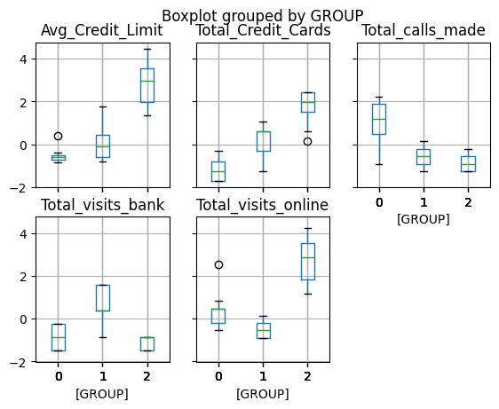

```python
# analyze data using boxplots

df_zscore.boxplot(by='GROUP', layout=(2,3));
```

There is very little overlapping data among the 3 groups, aside from "total bank visits" between group 0 and group 2.

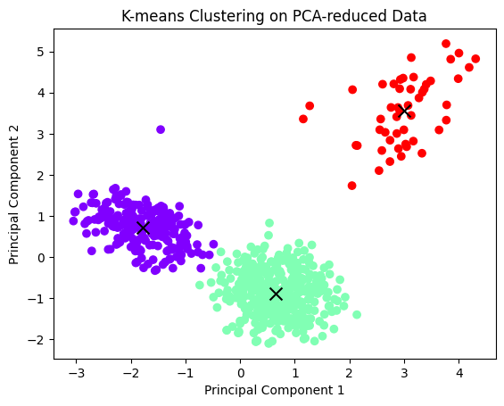

```python
# plot results in a scatter plot

plt.scatter(df_pca2[:, 0], df_pca2[:, 1], c=kmeans_predict, cmap='rainbow')
plt.scatter(kmeans.cluster_centers_[:, 0], kmeans.cluster_centers_[:, 1], c='black', marker='x', s=100)
plt.xlabel('Principal Component 1')
plt.ylabel('Principal Component 2')
plt.title('K-means Clustering on PCA-reduced Data')
plt.show()
```

## Hierarchical Clustering

```python
# execute hierarchical cluster on zscore

hier_model = AgglomerativeClustering(n_clusters=3, metric='euclidean', linkage='average')
hier_model.fit(df_zscore)

# append the result to data frame

df['LABEL'] = hier_model.labels_
df.head()
```

|  | Avg_Credit_Limit | Total_Credit_Cards | Total_visits_bank | Total_visits_online | Total_calls_made | GROUP | LABEL |
| --- | --- | --- | --- | --- | --- | --- | --- |
| 0 | 100000 | 2 | 1 | 1 | 0 | 1 | 0 |
| 1 | 50000 | 3 | 0 | 10 | 9 | 0 | 2 |
| 2 | 50000 | 7 | 1 | 3 | 4 | 1 | 0 |
| 3 | 30000 | 5 | 1 | 1 | 4 | 1 | 0 |
| 4 | 100000 | 6 | 0 | 12 | 3 | 2 | 1 |

```python
# analyze data of the clusters

cust_labels = df.groupby(['LABEL'])
cust_labels.mean()
```

| LABEL | Avg_Credit_Limit | Total_Credit_Cards | Total_visits_bank | Total_visits_online | Total_calls_made | GROUP |
| --- | --- | --- | --- | --- | --- | --- |
| 0 | 33604.712042 | 5.505236 | 3.494764 | 0.976440 | 2.005236 | 1.0 |
| 1 | 140102.040816 | 8.775510 | 0.591837 | 10.979592 | 1.102041 | 2.0 |
| 2 | 12174.107143 | 2.410714 | 0.933036 | 3.553571 | 6.870536 | 0.0 |

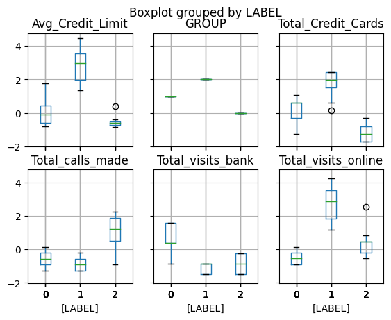

```python
# analyze data using boxplots

df_zscore['LABEL'] = hier_model.labels_
df_zscore.boxplot(by='LABEL', layout=(2,3));
```

```python
# visualize with dendrogram
linkage_matrix = linkage(df_zscore, method='average', metric='euclidean')
c, coph_dist = cophenet(linkage_matrix, pdist(df_zscore))
```

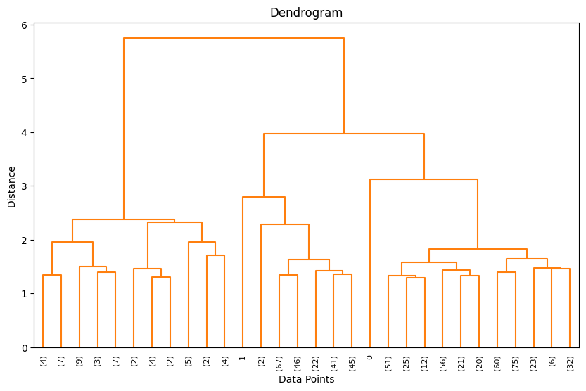

```python
plt.figure(figsize=(10, 6))
dendrogram(linkage_matrix, color_threshold=40, truncate_mode='lastp', leaf_rotation=90, leaf_font_size=8)
plt.title('Dendrogram')
plt.xlabel('Data Points')
plt.ylabel('Distance')
plt.show()
plt.tight_layout()
```

## Cluster Profiling and Comparison

```python
# compare data from k-means and hierarchical clusters

customers_groups = df.groupby(['GROUP'])
customers_groups.mean()
```

[output not shown]

```python
# relabel the groups of heirarchical clusters for better comparison

label_mapping = {0: 1, 1: 2, 2: 0}
# Applying label transformation
df['LABEL'] = df['LABEL'].map(label_mapping)

cust_labels = df.groupby(['LABEL'])
cust_labels.mean()
```

| LABEL | Avg_Credit_Limit | Total_Credit_Cards | Total_visits_bank | Total_visits_online | Total_calls_made | GROUP |
| --- | --- | --- | --- | --- | --- | --- |
| 0 | 12174.107143 | 2.410714 | 0.933036 | 3.553571 | 6.870536 | 0.0 |
| 1 | 33604.712042 | 5.505236 | 3.494764 | 0.976440 | 2.005236 | 1.0 |
| 2 | 140102.040816 | 8.775510 | 0.591837 | 10.979592 | 1.102041 | 2.0 |

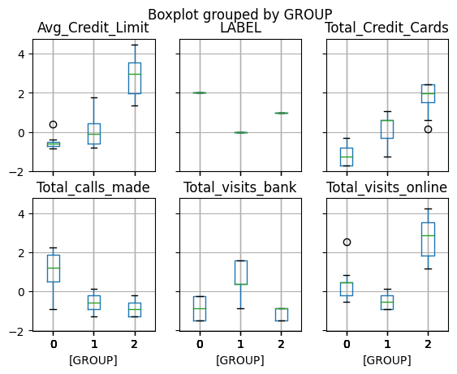

```python
# analyze boxplots of both methods

df_zscore.boxplot(by='GROUP', layout=(2,3));
```

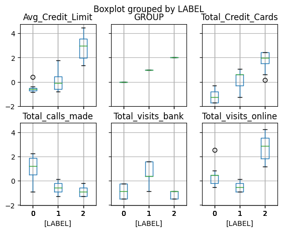

```python
df_zscore['LABEL'] = df_zscore['LABEL'].map(label_mapping)
df_zscore.boxplot(by='LABEL', layout=(2,3));
```

The clusters from both methods are identical.

## K-means vs Hierarchical Clustering

You compare several things, like:

- Which clustering technique took less time for execution?

  K-means took less time.
- Which clustering technique gave you more distinct clusters, or are they the same?

  They are the same.
- How many observations are there in the similar clusters of both algorithms?

  Both techniques provided identical clusters.
- How many clusters are obtained as the appropriate number of clusters from both algorithms?

  3 clusters.

You can also mention any differences or similarities you obtained in the cluster profiles from both the clustering techniques.

## Actionable Insights and Recommendations

We have segmented our customers into three distinct categories based on their credit limits: approximately \$12k, \$33k, and \$140k. Our strategic approach to engaging with each group is as follows:

Customers with approximately $12k credit limit:

We will proactively encourage this segment to embrace online checking to enhance their user experience and convenience. Regular follow-up calls will be made to understand their specific needs better and offer them tailored products and services. Customers with approximately $33k credit limit:

We aim to encourage this group to utilize online checking more frequently, ensuring seamless interactions with our platform. While promoting online usage, we will also prioritize in-person engagements to build strong, personalized relationships and offer our products. Customers with approximately $140k credit limit:

A key focus for this high-value segment will be online advertisements, strategically placed to capture their attention whenever they access our platform. Through targeted marketing campaigns, we will highlight our premium offerings to cater to their distinct requirements. By adopting these specialized approaches, we seek to optimize customer engagement, satisfaction, and ultimately drive growth in our product and service utilization across all credit limit tiers.

```python
%%shell
jupyter nbconvert /content/drive/MyDrive/Full_Code_AIML_USL_Project_CreditCardCustomerSegmentation.ipynb --to html
```

```
[NbConvertApp] Converting notebook /content/drive/MyDrive/Full_Code_AIML_USL_Project_CreditCardCustomerSegmentation.ipynb to html
[NbConvertApp] Writing 1514628 bytes to /content/drive/MyDrive/Full_Code_AIML_USL_Project_CreditCardCustomerSegmentation.html
```